# Maintain your brain, Minutes Aerobic Exercise

## ncal_msaerobic_wk

- Secondary Outcome: Minutes Aerobic Exercise

These results exclude those participants who were eligible for fewer than 2 modules but who were randomised. This results in N=6104.

```r
# read in functions and data
source("functions.R")
myb_dat <- read.csv(paste0("../../Data/",params$data,".csv"))  %>%
    mutate(rc_trial_time= as.factor(rc_trial_time))

library(glmmTMB)
library(DHARMa)
```

Inference for differences in rc_trial_time trend by group_type_id for ncal_msaerobic_wk

## Data summary

A 5-number summary is presented for the values here as the data are highly skewed.

```r
p <- c(0, 0.25, 0.5, 0.75, 1.00)
p_names <- map_chr(p, ~paste0(.x*100))
p_funs <- map(p, ~partial(quantile, probs = .x, na.rm = TRUE)) %>%
  set_names(nm = p_names)

# Percentiles
myb_dat %>%
  group_by(rc_trial_time, group_type_id) %>%
  summarize_at(vars(params$response), funs(!!!p_funs))
```

```
## # A tibble: 8 x 7
## # Groups:   rc_trial_time [4]
##   rc_trial_time group_type_id   `0`  `25`  `50`  `75` `100`
##   <fct>                 <int> <dbl> <dbl> <dbl> <dbl> <dbl>
## 1 1                         1     0     6   150  360   3960
## 2 1                         2     0     0   150  360   2764
## 3 10                        1     0     0   150  345   2670
## 4 10                        2     0    60   210  420   2506
## 5 11                        1     0    30   150  380.  3720
## 6 11                        2     0    75   240  480   2760
## 7 12                        1     0     0   150  360   3360
## 8 12                        2     0    60   220  448   2310
```

```r
# Means
myb_dat %>%
  group_by(.dots = lapply(params$predictors, as.symbol)) %>%
  summarize_at(.vars = params$response, .funs = list(Mean = mean, Sd = sd, N_obs = ~length(.)), na.rm=T)
```

```
## # A tibble: 8 x 5
## # Groups:   rc_trial_time [4]
##   rc_trial_time group_type_id  Mean    Sd N_obs
##   <fct>                 <int> <dbl> <dbl> <int>
## 1 1                         1  260.  349.  3053
## 2 1                         2  247.  315.  3051
## 3 10                        1  243.  298.  2128
## 4 10                        2  295.  323.  1507
## 5 11                        1  257.  311.  1906
## 6 11                        2  326.  353.  1357
## 7 12                        1  252.  309.  1961
## 8 12                        2  309.  328.  1377
```

### Histograms

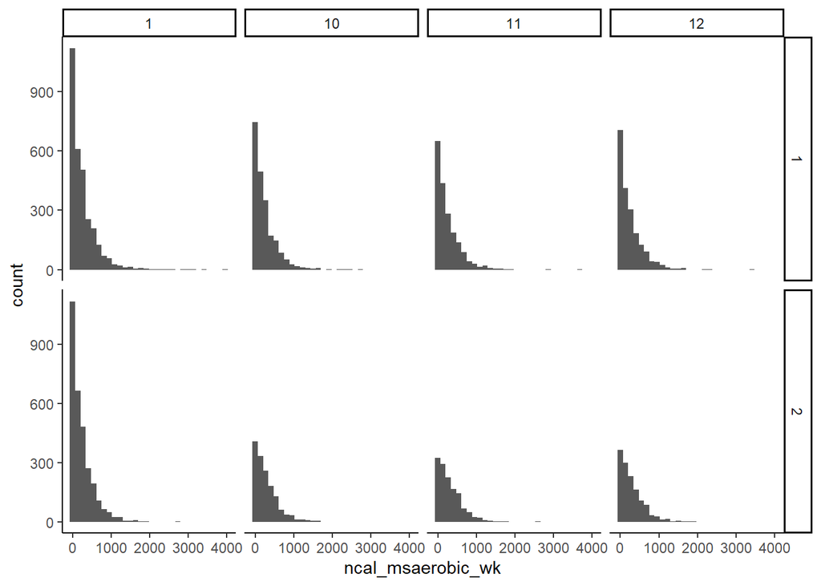

```r
myb_dat %>% ggplot(aes(x=ncal_msaerobic_wk)) + geom_histogram() +
  facet_grid(group_type_id~rc_trial_time) + theme_classic()
```

```r
# if want to run
if(!params$final){
  # if(FALSE){
  # run models


  unadj_mod <- glmmTMB(ncal_msaerobic_wk ~   rc_trial_time*group_type_id + (1 | id_mask) ,
                       data=myb_dat, family = tweedie )
  unadj_null <- glmmTMB(ncal_msaerobic_wk ~ rc_trial_time + group_type_id + (1 | id_mask) ,
                        data=myb_dat, family = tweedie )
  adj_mod <- glmmTMB(ncal_msaerobic_wk ~ myb_age + myb_gender + cl_edu_yrs + rcal_modules_sum +
                       adri_baseline + rc_trial_time * group_type_id + (1 | id_mask) ,
                     data=myb_dat, family = tweedie )
  adj_null <- glmmTMB(ncal_msaerobic_wk ~ myb_age + myb_gender + cl_edu_yrs + rcal_modules_sum +
                        adri_baseline + rc_trial_time + group_type_id + (1 | id_mask) ,
                      data=myb_dat, family = tweedie )

  # save models
  save(unadj_mod,file = paste0("../../Results/baseline_sd/",params$response,"_unadj_mod"))
  save(unadj_null,file = paste0("../../Results/baseline_sd/",params$response,"_unadj_null"))
  save(adj_mod,file = paste0("../../Results/baseline_sd/",params$response,"_adj_mod"))
  save(adj_null,file = paste0("../../Results/baseline_sd/",params$response,"_adj_null"))

} else {
  load(file = paste0("../../Results/baseline_sd/",params$response,"_unadj_mod"))
  load(file = paste0("../../Results/baseline_sd/",params$response,"_unadj_null"))
  load(file = paste0("../../Results/baseline_sd/",params$response,"_adj_mod"))
  load(file = paste0("../../Results/baseline_sd/",params$response,"_adj_null"))
  }

fitted_mods = list(adj_mod = adj_mod,
              unadj_null = unadj_null,
              unadj_mod = unadj_mod,
              adj_null = adj_null)
```

```r
#plot models


if(!params$final){
  # if(FALSE){
  # lapply(fitted_mods, plot, form = cond)

  # sim= simulateResiduals(unadj_mod, n = 5000)
  # resid = residuals(sim, quantileFunction = qnorm, outlierValues = c(-7,7))
  # scatter.smooth(resid~predict(unadj_mod, re.form = NA,type="response"),
  #                lpars =list(col = "red", lwd = 3, lty = 3))
  #
  # sim= simulateResiduals(adj_mod, n = 5000)
  # resid = residuals(sim, quantileFunction = qnorm, outlierValues = c(-7,7))
  # scatter.smooth(resid~predict(adj_mod, re.form = NA,type="response"),
  #                lpars =list(col = "red", lwd = 3, lty = 3))
  #
  # sim= simulateResiduals(unadj_null, n = 5000)
  # resid = residuals(sim, quantileFunction = qnorm, outlierValues = c(-7,7))
  # scatter.smooth(resid~predict(unadj_null, re.form = NA,type="response"),
  #                lpars =list(col = "red", lwd = 3, lty = 3))
  #
  # sim= simulateResiduals(adj_null, n = 5000)
  # resid = residuals(sim, quantileFunction = qnorm, outlierValues = c(-7,7))
  # scatter.smooth(resid~predict(adj_null, re.form = NA,type="response"),
  #                lpars =list(col = "red", lwd = 3, lty = 3))


  }
```

```r
#check summary is okay

if(!params$final){
  summary(unadj_null)
  summary(unadj_mod)
  summary(adj_null)
  summary(adj_mod)
}
```

```
##  Family: tweedie  ( log )
## Formula:
## ncal_msaerobic_wk ~ myb_age + myb_gender + cl_edu_yrs + rcal_modules_sum +
##     adri_baseline + rc_trial_time * group_type_id + (1 | id_mask)
## Data: myb_dat
##
##      AIC      BIC   logLik deviance df.resid
## 183549.5 183672.7 -91758.7 183517.5    16322
##
## Random effects:
##
## Conditional model:
##  Groups  Name        Variance Std.Dev.
##  id_mask (Intercept) 0.8317   0.912
## Number of obs: 16338, groups:  id_mask, 6103
##
## Dispersion parameter for tweedie family (): 37.2
##
## Conditional model:
##                                Estimate Std. Error z value Pr(>|z|)
## (Intercept)                    4.138674   0.245656  16.847  < 2e-16 ***
## myb_age                        0.015816   0.003185   4.965 6.86e-07 ***
## myb_genderMale                 0.340358   0.029935  11.370  < 2e-16 ***
## cl_edu_yrs                     0.008955   0.004860   1.843   0.0654 .
## rcal_modules_sum              -0.124322   0.022612  -5.498 3.84e-08 ***
## adri_baseline                 -0.037357   0.002350 -15.898  < 2e-16 ***
## rc_trial_time10               -0.337509   0.054111  -6.237 4.45e-10 ***
## rc_trial_time11               -0.325898   0.055539  -5.868 4.41e-09 ***
## rc_trial_time12               -0.301738   0.055330  -5.453 4.94e-08 ***
## group_type_id                 -0.016478   0.032213  -0.512   0.6090
## rc_trial_time10:group_type_id  0.254849   0.035398   7.200 6.04e-13 ***
## rc_trial_time11:group_type_id  0.291615   0.036210   8.054 8.05e-16 ***
## rc_trial_time12:group_type_id  0.249725   0.036209   6.897 5.32e-12 ***
## ---
## Signif. codes:  0 '***' 0.001 '**' 0.01 '*' 0.05 '.' 0.1 ' ' 1
```

## Results

```r
if(!params$final){


  #unadjusted
  anova_call <- anova(unadj_null,unadj_mod)
  likrat <-  data.frame(Chisq = paste0(round(anova_call$Chisq[2],3),"(",
                                       anova_call$Df[2],")"),
                        pvalue = anova_call$`Pr(>Chisq)`[2])
  em <- emmeans(unadj_mod,  ~ rc_trial_time*group_type_id , type = "response",
                at = list(rc_trial_time = plannedtimes) )
  cont <- contrast(em, interaction = c("consec", "consec"))
  CI <- confint(cont)
  Su <- summary(cont)
  coef <- as.data.frame(cont)$ratio
  confint <- CI[,c("asymp.LCL", "asymp.UCL")]


  zstat = round(Su$z.ratio,3)
  pz = ifelse (Su$p.value < 0.001, "<0.001",paste("= ",round(Su$p.value,3)))
  unadj_res = cbind(coef = coef, confint, zstat = zstat, pz = pz, likrat)

  #adjusted

  anova_call <- anova(adj_null,adj_mod)
  likrat <-  data.frame(Chisq = paste0(round(anova_call$Chisq[2],3),"(",
                                       anova_call$Df[2],")"),
                        pvalue = anova_call$`Pr(>Chisq)`[2])
  em <- emmeans(adj_mod,  ~ rc_trial_time*group_type_id , type = "response",
                at = list(rc_trial_time = plannedtimes) )
  cont <- contrast(em, interaction = c("consec", "consec"))
  CI <- confint(cont)
  Su <- summary(cont)
  coef <- as.data.frame(cont)$ratio
  confint <- CI[,c("asymp.LCL", "asymp.UCL")]


  zstat = round(Su$z.ratio,3)
  pz = ifelse (Su$p.value < 0.001, "<0.001",paste("= ",round(Su$p.value,3)))
  adj_res = cbind(coef = coef, confint, zstat = zstat, pz = pz, likrat)


  # calculate CI
  res_tab <- rbind(adj_res,unadj_res) %>%
    as.data.frame() %>%
    remove_rownames %>%
    mutate(response = params$response,
           adjusted = c("No","Yes")) %>%
    transmute(response, adjusted,
              planned = coef, asymp.LCL = asymp.LCL, asymp.UCL = asymp.UCL,
              Chisq, p.value = pvalue)



  # save models
  write.csv(res_tab,file = paste0("../../Results/baseline_sd/",params$response,"_table.csv"), row.names = FALSE)



} else {
  res_tab <- read.csv(file = paste0("../../Results/baseline_sd/",params$response,"_table.csv"))


}

res <- res_tab %>%
  transmute(response,
            adjusted,
            base_3yr_ratio = round(planned,3),
            LCL = round(asymp.LCL,3),
            UCL = round(asymp.UCL,3),
            zstat,
            pz,
            Chisq,
            `p.value` = ifelse (`p.value` < 0.001, "<0.001",paste("= ",round(`p.value`,3)))
)

res
```

```
##            response adjusted base_3yr_ratio   LCL   UCL zstat     pz      Chisq
## 1 ncal_msaerobic_wk       No          1.284 1.196 1.378 6.897 <0.001 88.469(16)
## 2 ncal_msaerobic_wk      Yes          1.287 1.198 1.382 6.897 <0.001 87.529(11)
##   p.value
## 1  <0.001
## 2  <0.001
```

```r
evidence_unadj = ifelse(res_tab$p.value[1]<0.05, "evidence", "no evidence")
evidence_adj = ifelse(res_tab$p.value[2]<0.05, "evidence", "no evidence")
```

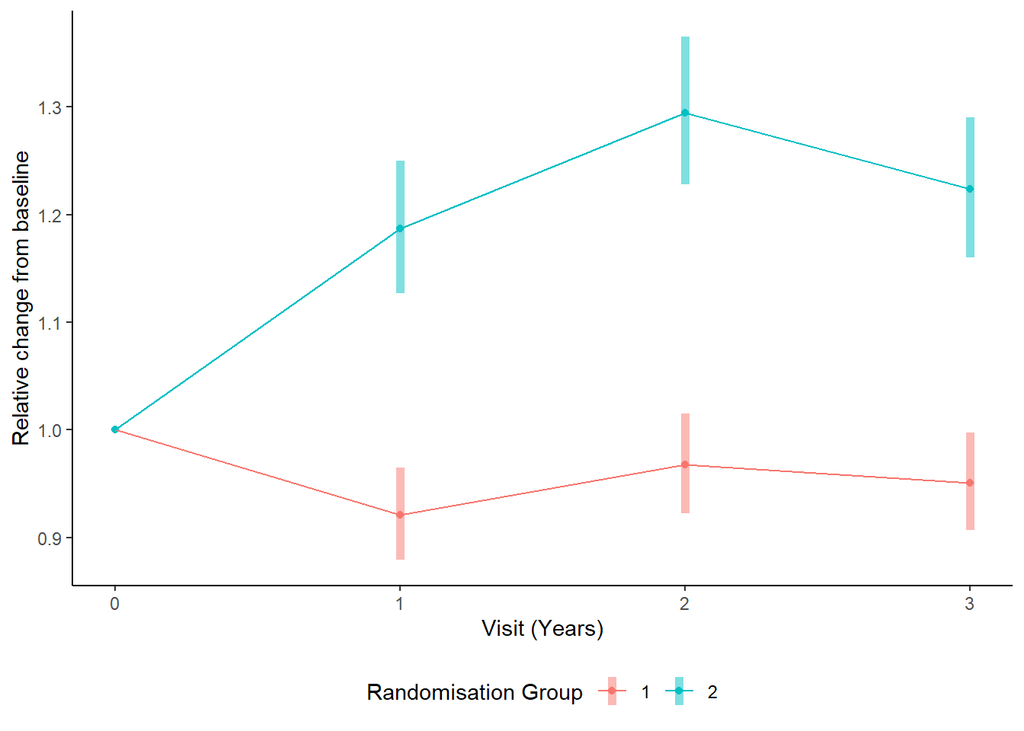

```r
# calculate all ems by time and group
group_time_ems <- emmeans(fitted_mods$unadj_mod,  ~ group_type_id  + rc_trial_time, type = "response")

# contrast to baseline by group
comp_to_baseline <- contrast(group_time_ems, rc_trial_time , "trt.vs.ctrl", by=  "group_type_id")

time_diff <- c(1:3)

to_bl_plot_df <- cbind(summary(comp_to_baseline)[,1:3],
                       confint(comp_to_baseline)[,6:7],
                       `Visit (Years)` = rep(c(1:3), 2))
# add baseline 0
to_bl_plot_df[7:8,] <- NA
to_bl_plot_df$group_type_id[7:8] = c(1,2)
to_bl_plot_df$ratio[7:8] = c(1,1)
to_bl_plot_df$`Visit (Years)`[7:8] = 0


to_bl_plot_df %>%
  ggplot(aes(`Visit (Years)`, ratio, color=factor(group_type_id), group=factor(group_type_id))) +
  geom_point() +
  geom_line()+
  geom_linerange(aes(ymin=asymp.LCL, ymax=asymp.UCL), size=2, alpha=.5) +
  theme_classic() +
  ylab("Relative change from baseline") +
  scale_color_discrete(name="Randomisation Group")  +
   theme(legend.position = "bottom")
```

```r
ggsave(file = paste0(params$response,"_",params$data,"_plot.png"), width = 12, height = 8, units = "cm")
to_bl_plot_df %>%
  transmute(group_type_id, `Visit (Years)`,
         ratio,
         LCL = asymp.LCL, UCL = asymp.UCL) %>%
  arrange(`Visit (Years)`,group_type_id) %>%
write.csv(file = paste0(params$response,"_",params$data,"_plotdata.csv"), row.names = FALSE)



ratios_adj <- emmeans(fitted_mods$adj_mod, trt.vs.ctrl ~ group_type_id  + rc_trial_time, type = "response", by=  "group_type_id", adjust = NULL) $contrasts[c(3,6)] %>% confint()

ratios_adj[,3:7] <- round(ratios_adj[,3:7],2)

ratios_unadj <- emmeans(fitted_mods$unadj_mod, trt.vs.ctrl ~ group_type_id  + rc_trial_time, type = "response", by=  "group_type_id", adjust = NULL) $contrasts[c(3,6)] %>% confint()

ratios_unadj[,3:7] <- round(ratios_unadj[,3:7],2)
```

## Result

These data are positively skewed and bounded by 0. As such, a normal disitrubution is not recommended. We tried a number of GLMMs with capacity to handle such distributions, and concluded a tweedie distribution was most appropriate for these data.

. Covariates included in adjusted models:

- `myb_age`: Age at Baseline
- `myb_gender`: Reported gender
- `cl_edu_yrs`: Years of education
- `rcal_modules_sum`: Number of modules person was eligible for
- `adri_baseline`: ADRI at Baseline

A tweedie mixed model with a random effect for individual and fixed effects of time point, randomisation group and their interaction was run. An additional analysis including covariates of myb_age, myb_gender, cl_edu_yrs, rcal_modules_sum, adri_baseline was run. We report estimate and confidence interval for the relative change in minutes per week within each group, with assoicated z statistic and p-value.

For group = 1, the unadjusted estimated relative change is 0.95 from baseline to 3 years (95%CI 0.91 - 1), for group 2, the estimated relative change is 1.22 from baseline to 3 years (95%CI 1.16 - 1.29). The unadjusted ratio between randomisation groups of relative change from baseline to three year follow up was 1.284 ( 95%CI: 1.196- 1.378, Z=6.897,p<0.001 ).

Analysis by Nancy Briggs and Gordana Popovic on 2024-02-14